# Problem Statement

## Using the Source data sets, Identify the Top Revenue Loss(>1000 Dollors) Products which are Cancelled by the Customer

# Solution

## Use the Open Source PYSPARK (ETL), Extract, Transform & Aggregate the data as per the requirement

## Source Data (Orders, Order_Items & Products) are available as .csv files in (Local File Sytem)

## PYSPARK - Using Python API for Spark

## RDD - Resilient distributed dataset for Transformations/Actions

## DATAFRAME for Transformations & Aggregations

## MATPLOTLIB for Data Visualization

## Source Data Schema Details

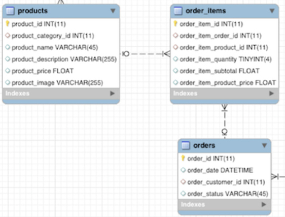

## Create the Spark Context using local mode

```python
from pyspark import SparkContext, SparkConf
conf = SparkConf().setAppName("revenueloss").setMaster("local")
sc = SparkContext(conf=conf)
```

## Create RDD's using the implicit spark context("sc")

### Read orders data

```python
orders = sc.textFile("/home/datamaking/data/data-master/retail_db/orders/orders.csv")
for i in orders.take(5): print(i)
orders.count()
```

```
1,2013-07-25 00:00:00.0,11599,CLOSED
2,2013-07-25 00:00:00.0,256,PENDING_PAYMENT
3,2013-07-25 00:00:00.0,12111,COMPLETE
4,2013-07-25 00:00:00.0,8827,CLOSED
5,2013-07-25 00:00:00.0,11318,COMPLETE
```

```
68883
```

### Read OrderItems Data

```python
orderItems = sc.textFile("/home/datamaking/data/data-master/retail_db/order_items/order-items.csv")
for i in orderItems.take(5): print(i)
orderItems.count()
```

```
1,1,957,1,299.98,299.98
2,2,1073,1,199.99,199.99
3,2,502,5,250.0,50.0
4,2,403,1,129.99,129.99
5,4,897,2,49.98,24.99
```

```
172198
```

### Display the distinct order status

```python
for i in orders.map(lambda o: o.split(",")[3]).distinct().collect():
	print(i)
```

```
CLOSED
PENDING_PAYMENT
COMPLETE
PROCESSING
PAYMENT_REVIEW
PENDING
ON_HOLD
CANCELED
SUSPECTED_FRAUD
```

### Filter for CANCELLED Orders

```python
ordersFiltered = orders.filter(lambda o: o.split(",")[3] in ["CANCELED"])
for i in ordersFiltered.take(5):
	print(i)
```

```
50,2013-07-25 00:00:00.0,5225,CANCELED
112,2013-07-26 00:00:00.0,5375,CANCELED
527,2013-07-28 00:00:00.0,5426,CANCELED
552,2013-07-28 00:00:00.0,1445,CANCELED
564,2013-07-28 00:00:00.0,2216,CANCELED
```

### Count the number of CANCELLED Orders

```python
ordersFiltered.count()
```

```
1428
```

### Perform the Pair RDD's using key value pairs using orders and order-items data ( common attribute order-id from both the data sources)

```python
ordersMap = ordersFiltered. \
	map(lambda o: (int(o.split(",")[0]), o.split(",")[1]))

orderItemsMap = orderItems. \
	map(lambda oi:
		 (int(oi.split(",")[1]), (int(oi.split(",")[2]), float(oi.split(",")[4]))))
```

### #Preview the sample 5 records of ordersMap and ordersItemMap

```python
for i in ordersMap.take(5):
	print(i)

for i in orderItemsMap.take(5):
	print(i)
```

```
(50, '2013-07-25 00:00:00.0')
(112, '2013-07-26 00:00:00.0')
(527, '2013-07-28 00:00:00.0')
(552, '2013-07-28 00:00:00.0')
(564, '2013-07-28 00:00:00.0')
(1, (957, 299.98))
(2, (1073, 199.99))
(2, (502, 250.0))
(2, (403, 129.99))
(4, (897, 49.98))
```

### Join orders and orderitems data using the pair RDD's (ordersMap and orderItemsMap)

```python
ordersJoin = ordersMap.join(orderItemsMap)

for i in ordersJoin.take(5):
	print(i)
```

```
(50, ('2013-07-25 00:00:00.0', (403, 129.99)))
(50, ('2013-07-25 00:00:00.0', (957, 299.98)))
(112, ('2013-07-26 00:00:00.0', (1014, 99.96)))
(112, ('2013-07-26 00:00:00.0', (642, 120.0)))
(112, ('2013-07-26 00:00:00.0', (365, 119.98)))
```

### Need to convert the data(ordersJoin) as below using the map function

### (12, ('2013-07-25 00:00:00.0', (957, 299.98))) -> ((2013-07-25 00:00:00.0, 957), 299.98)

```python
ordersJoinMap = ordersJoin. \
map(lambda o: ((o[1][0],o[1][1][0]), o[1][1][1]))

for i in ordersJoinMap.take(5):
	print(i)
```

```
(('2013-07-25 00:00:00.0', 403), 129.99)
(('2013-07-25 00:00:00.0', 957), 299.98)
(('2013-07-26 00:00:00.0', 1014), 99.96)
(('2013-07-26 00:00:00.0', 642), 120.0)
(('2013-07-26 00:00:00.0', 365), 119.98)
```

### Aggregate to get the daily revenue loss per product id using reduceby key

```python
from operator import add
dailyRevenueLossPerProductId = ordersJoinMap.reduceByKey(add)

for i in dailyRevenueLossPerProductId.take(5):
	print(i)
```

```
(('2013-07-25 00:00:00.0', 403), 129.99)
(('2013-07-25 00:00:00.0', 957), 299.98)
(('2013-07-26 00:00:00.0', 1014), 149.94)
(('2013-07-26 00:00:00.0', 642), 120.0)
(('2013-07-26 00:00:00.0', 1004), 399.98)
```

### Read products data

```python
products = sc.textFile("/home/datamaking/data/data-master/retail_db/products/part-00000")

for i in products.take(5):
	print(i)
```

```
1,2,Quest Q64 10 FT. x 10 FT. Slant Leg Instant U,,59.98,http://images.acmesports.sports/Quest+Q64+10+FT.+x+10+FT.+Slant+Leg+Instant+Up+Canopy
2,2,Under Armour Men's Highlight MC Football Clea,,129.99,http://images.acmesports.sports/Under+Armour+Men%27s+Highlight+MC+Football+Cleat
3,2,Under Armour Men's Renegade D Mid Football Cl,,89.99,http://images.acmesports.sports/Under+Armour+Men%27s+Renegade+D+Mid+Football+Cleat
4,2,Under Armour Men's Renegade D Mid Football Cl,,89.99,http://images.acmesports.sports/Under+Armour+Men%27s+Renegade+D+Mid+Football+Cleat
5,2,Riddell Youth Revolution Speed Custom Footbal,,199.99,http://images.acmesports.sports/Riddell+Youth+Revolution+Speed+Custom+Football+Helmet
```

### Create a key value pair using the map and tuples

```python
productsMap = products. \
map(lambda p: (int(p.split(",")[0]), p.split(",")[2]))


for i in productsMap.take(5):
	print(i)
```

```
(1, 'Quest Q64 10 FT. x 10 FT. Slant Leg Instant U')
(2, "Under Armour Men's Highlight MC Football Clea")
(3, "Under Armour Men's Renegade D Mid Football Cl")
(4, "Under Armour Men's Renegade D Mid Football Cl")
(5, 'Riddell Youth Revolution Speed Custom Footbal')
```

### Create a key value pair using the map and tuples for RDD Pair (dailyRevenueLossPerProductId) to join the products data

```python
dailyRevenueLossPerProductIdMap = dailyRevenueLossPerProductId. \
map(lambda r: (r[0][1], (r[0][0], r[1])))

for i in dailyRevenueLossPerProductIdMap.take(5):
	print(i)
```

```
(403, ('2013-07-25 00:00:00.0', 129.99))
(957, ('2013-07-25 00:00:00.0', 299.98))
(1014, ('2013-07-26 00:00:00.0', 149.94))
(642, ('2013-07-26 00:00:00.0', 120.0))
(1004, ('2013-07-26 00:00:00.0', 399.98))
```

## Create the final RDD contains the Product id, name, date and revenue loss amount

```python
dailyRevenueLossPerProductIdMapFinal = productsMap.join(dailyRevenueLossPerProductIdMap)
dailyRevLossPerProduct = dailyRevenueLossPerProductIdMapFinal. \
map(lambda t : (t[0], t[1][0], t[1][1][0], t[1][1][1]))
for i in dailyRevLossPerProduct.take(10):
    print(i)
```

```
(93, "Under Armour Men's Tech II T-Shirt", '2014-04-12 00:00:00.0', 49.98)
(93, "Under Armour Men's Tech II T-Shirt", '2013-10-31 00:00:00.0', 99.96)
(93, "Under Armour Men's Tech II T-Shirt", '2013-08-21 00:00:00.0', 24.99)
(93, "Under Armour Men's Tech II T-Shirt", '2013-08-29 00:00:00.0', 24.99)
(93, "Under Armour Men's Tech II T-Shirt", '2013-11-20 00:00:00.0', 124.95)
(93, "Under Armour Men's Tech II T-Shirt", '2013-11-28 00:00:00.0', 99.96)
(135, 'Nike Dri-FIT Crew Sock 6 Pack', '2014-03-22 00:00:00.0', 22.0)
(135, 'Nike Dri-FIT Crew Sock 6 Pack', '2013-09-02 00:00:00.0', 88.0)
(135, 'Nike Dri-FIT Crew Sock 6 Pack', '2014-02-03 00:00:00.0', 22.0)
(135, 'Nike Dri-FIT Crew Sock 6 Pack', '2014-04-24 00:00:00.0', 110.0)
```

## Convert RDD into the DataFrame with Schema and preview the data

```python
dailyRevLossPerProductDF = dailyRevLossPerProduct.toDF(['productId','productName','cancelledDate','revenueLossAmt'])
dailyRevLossPerProductDF.head(5)
```

```
[Row(productId=93, productName="Under Armour Men's Tech II T-Shirt", cancelledDate='2014-04-12 00:00:00.0', revenueLossAmt=49.98),
 Row(productId=93, productName="Under Armour Men's Tech II T-Shirt", cancelledDate='2013-10-31 00:00:00.0', revenueLossAmt=99.96),
 Row(productId=93, productName="Under Armour Men's Tech II T-Shirt", cancelledDate='2013-08-21 00:00:00.0', revenueLossAmt=24.99),
 Row(productId=93, productName="Under Armour Men's Tech II T-Shirt", cancelledDate='2013-08-29 00:00:00.0', revenueLossAmt=24.99),
 Row(productId=93, productName="Under Armour Men's Tech II T-Shirt", cancelledDate='2013-11-20 00:00:00.0', revenueLossAmt=124.95)]
```

```python
dailyRevLossPerProductDFSort = dailyRevLossPerProductDF.orderBy(dailyRevLossPerProductDF.revenueLossAmt.desc())
dailyRevLossPerProductDFSort.show()
```

```
+---------+--------------------+--------------------+--------------+
|productId|         productName|       cancelledDate|revenueLossAmt|
+---------+--------------------+--------------------+--------------+
|     1004|Field & Stream Sp...|2013-11-03 00:00:...|       2399.88|
|     1004|Field & Stream Sp...|2014-05-09 00:00:...|       2399.88|
|     1004|Field & Stream Sp...|2014-01-28 00:00:...|        1999.9|
|     1004|Field & Stream Sp...|2014-04-09 00:00:...|        1999.9|
|     1004|Field & Stream Sp...|2013-12-05 00:00:...|        1999.9|
|     1004|Field & Stream Sp...|2014-04-29 00:00:...|        1999.9|
|     1004|Field & Stream Sp...|2013-10-13 00:00:...|        1999.9|
|      860|Bushnell Pro X7 J...|2014-03-26 00:00:...|       1799.97|
|      957|Diamondback Women...|2013-09-02 00:00:...|       1799.88|
|      191|Nike Men's Free 5...|2014-02-25 00:00:...|       1699.83|
|     1004|Field & Stream Sp...|2014-07-22 00:00:...|       1599.92|
|     1004|Field & Stream Sp...|2014-02-19 00:00:...|       1599.92|
|     1004|Field & Stream Sp...|2013-12-17 00:00:...|       1599.92|
|     1004|Field & Stream Sp...|2014-07-18 00:00:...|       1599.92|
|     1004|Field & Stream Sp...|2014-02-04 00:00:...|       1599.92|
|     1004|Field & Stream Sp...|2013-09-24 00:00:...|       1599.92|
|     1004|Field & Stream Sp...|2013-10-06 00:00:...|       1599.92|
|     1004|Field & Stream Sp...|2014-02-10 00:00:...|       1599.92|
|      957|Diamondback Women...|2014-07-23 00:00:...|        1499.9|
|      191|Nike Men's Free 5...|2014-03-20 00:00:...|       1399.86|
+---------+--------------------+--------------------+--------------+
only showing top 20 rows
```

```python
dailyRevLossPerProductFilter = dailyRevLossPerProductDFSort.filter(dailyRevLossPerProductDFSort.revenueLossAmt > 1000.00)
```

```python
dailyRevLossPerProductFilter.show()
```

```
+---------+--------------------+--------------------+--------------+
|productId|         productName|       cancelledDate|revenueLossAmt|
+---------+--------------------+--------------------+--------------+
|     1004|Field & Stream Sp...|2014-05-09 00:00:...|       2399.88|
|     1004|Field & Stream Sp...|2013-11-03 00:00:...|       2399.88|
|     1004|Field & Stream Sp...|2014-04-09 00:00:...|        1999.9|
|     1004|Field & Stream Sp...|2013-10-13 00:00:...|        1999.9|
|     1004|Field & Stream Sp...|2013-12-05 00:00:...|        1999.9|
|     1004|Field & Stream Sp...|2014-01-28 00:00:...|        1999.9|
|     1004|Field & Stream Sp...|2014-04-29 00:00:...|        1999.9|
|      860|Bushnell Pro X7 J...|2014-03-26 00:00:...|       1799.97|
|      957|Diamondback Women...|2013-09-02 00:00:...|       1799.88|
|      191|Nike Men's Free 5...|2014-02-25 00:00:...|       1699.83|
|     1004|Field & Stream Sp...|2014-07-22 00:00:...|       1599.92|
|     1004|Field & Stream Sp...|2014-02-04 00:00:...|       1599.92|
|     1004|Field & Stream Sp...|2013-10-06 00:00:...|       1599.92|
|     1004|Field & Stream Sp...|2014-07-18 00:00:...|       1599.92|
|     1004|Field & Stream Sp...|2013-09-24 00:00:...|       1599.92|
|     1004|Field & Stream Sp...|2014-02-19 00:00:...|       1599.92|
|     1004|Field & Stream Sp...|2014-02-10 00:00:...|       1599.92|
|     1004|Field & Stream Sp...|2013-12-17 00:00:...|       1599.92|
|      957|Diamondback Women...|2014-07-23 00:00:...|        1499.9|
|      191|Nike Men's Free 5...|2014-03-20 00:00:...|       1399.86|
+---------+--------------------+--------------------+--------------+
only showing top 20 rows
```

```python
dailyRevLossPerProductSort = dailyRevLossPerProductFilter.orderBy(dailyRevLossPerProductFilter.productId)
dailyRevLossPerProductSort.show()
```

```
+---------+--------------------+--------------------+------------------+
|productId|         productName|       cancelledDate|    revenueLossAmt|
+---------+--------------------+--------------------+------------------+
|      191|Nike Men's Free 5...|2014-03-20 00:00:...|           1399.86|
|      191|Nike Men's Free 5...|2014-07-07 00:00:...|1199.8799999999999|
|      191|Nike Men's Free 5...|2014-02-25 00:00:...|           1699.83|
|      191|Nike Men's Free 5...|2013-10-06 00:00:...|1299.8700000000001|
|      191|Nike Men's Free 5...|2013-09-16 00:00:...|           1299.87|
|      191|Nike Men's Free 5...|2014-03-14 00:00:...|           1399.86|
|      191|Nike Men's Free 5...|2014-04-01 00:00:...|1299.8700000000001|
|      191|Nike Men's Free 5...|2014-07-03 00:00:...|           1099.89|
|      365|Perfect Fitness P...|2014-05-11 00:00:...|           1079.82|
|      365|Perfect Fitness P...|2014-05-09 00:00:...|           1259.79|
|      365|Perfect Fitness P...|2013-08-30 00:00:...|1019.8299999999999|
|      365|Perfect Fitness P...|2014-05-18 00:00:...|           1319.78|
|      365|Perfect Fitness P...|2013-12-01 00:00:...|1019.8299999999999|
|      365|Perfect Fitness P...|2014-03-23 00:00:...|1019.8299999999999|
|      365|Perfect Fitness P...|2014-06-27 00:00:...|           1019.83|
|      365|Perfect Fitness P...|2014-05-02 00:00:...|1019.8299999999999|
|      502|Nike Men's Dri-FI...|2014-05-09 00:00:...|            1100.0|
|      860|Bushnell Pro X7 J...|2014-03-26 00:00:...|           1799.97|
|      957|Diamondback Women...|2013-09-16 00:00:...|           1199.92|
|      957|Diamondback Women...|2013-09-02 00:00:...|           1799.88|
+---------+--------------------+--------------------+------------------+
only showing top 20 rows
```

```python
import pyspark.sql.functions as f

dailyRevLossPerProductGroup = dailyRevLossPerProductSort.groupBy('productName').agg(f.max('revenueLossAmt'))
```

```python
dailyRevLossPerProductGroup.show()
```

```
+--------------------+-------------------+
|         productName|max(revenueLossAmt)|
+--------------------+-------------------+
|Field & Stream Sp...|            2399.88|
|Nike Men's Dri-FI...|             1100.0|
|Perfect Fitness P...|            1319.78|
|Diamondback Women...|            1799.88|
|Nike Men's Free 5...|            1699.83|
|Bushnell Pro X7 J...|            1799.97|
+--------------------+-------------------+
```

```python
import matplotlib.pyplot as plt
import pandas as pd
from pyspark.sql.types import *
```

```python
x=dailyRevLossPerProductGroup.toPandas()["productName"].values.tolist()
y=dailyRevLossPerProductGroup.toPandas()["max(revenueLossAmt)"].values.tolist()
```

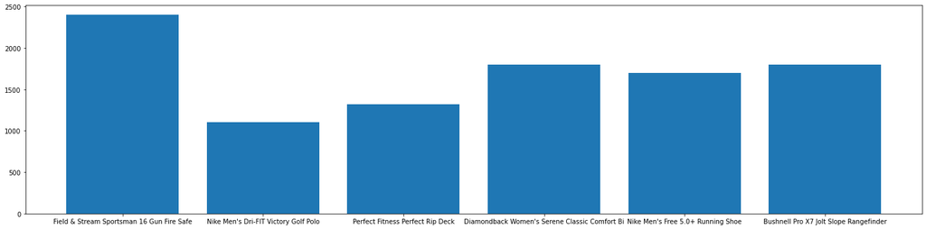

```python
plt.rcParams['figure.figsize'] = (25,6)
plt.bar(x,y)
plt.show()
```